# Analysis

# Step 0

Getting the data

In the following chunk of code, we used the data from the Living Repository - 2021 Excel file. We extracted the initiatives whose Status are ‘Sent to evaluators’ OR ‘Information complete’. The main objective of this document is to find the initiatives that are similar (or different) to each other word_wise; i.e. the similarity degree of each pair of initiatives with regards to the words that used to explain their Description and/or thier Mission.

# Step 1

After reading the data from the Living Repository, we counted the number of words used in the “Description” and the “Mission” columns. The aim of the following chunk of code is counting the number of times each word has been used in each initiative. Note that some of the common words such as ‘covid’, ‘19’, ‘2’ or ‘50’ have been excluded.

```r
text_data = data %>%
  mutate(initiative = row_number()) %>%
  unite(text, Description:Mission, sep = " | ") %>%
  select(initiative, text)

words = text_data %>%
  unnest_tokens(word, text)


custom_stopwords = c("covid","19","2","50")

words = words %>%
  anti_join(stop_words) %>%
  count(initiative, word, sort = TRUE) %>%
  filter(!word %in% custom_stopwords )
words %>%
  arrange(desc(n))
```

| initiative | word | n |
| --- | --- | --- |
| 15 | drug | 12 |
| 4 | mortality | 8 |
| 5 | patients | 7 |
| 12 | forecast | 7 |
| 15 | combinations | 7 |
| 3 | protein | 6 |
| 14 | protein | 6 |
| 15 | identif.ai | 6 |
| 16 | mobile | 6 |
| 20 | health | 6 |

[output cut: 990 more lines]

# Step 2

In this step, we considered the words that have been used more than 3 times. Note that these values are across the whole initiatives. For example, the word “data” has been used has been used more than 25 times across all the initiatives.

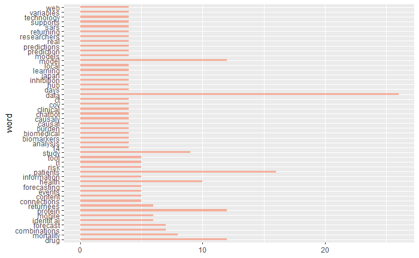

```r
words %>%
  filter(n > 3) %>%
  arrange(n) %>%
  mutate(word = fct_reorder(word, desc(n))) %>%
  ggplot(aes(word, n)) +
  geom_bar(stat = "identity", fill = "#f68060", alpha = .6, width = .4) +
  coord_flip() +
  labs(y = NULL)
```

# Step 3

## Generating Topics

```r
words_dtm = words %>%
  cast_dtm(initiative, word, n)
```

```r
# Compute the K value "scores" from K=4 to K=45
result = FindTopicsNumber(
    words_dtm,
    topics = seq(from = 2, to = 25, by = 1),
    metrics = c("Griffiths2004", "CaoJuan2009", "Arun2010", "Deveaud2014"),
    method = "Gibbs",
    control = list(seed = 1948),
    mc.cores = 2L,
    verbose = TRUE
)
```

```
fit models... done.
calculate metrics:
  Griffiths2004... done.
  CaoJuan2009... done.
  Arun2010... done.
  Deveaud2014... done.
```

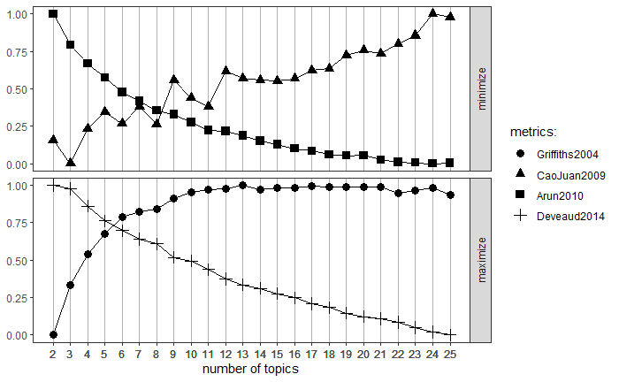

```r
FindTopicsNumber_plot(result)
```

Now that we have the number of clusters that the words can be fitted in, we can see the members of each cluster. Note that some clusters overlap with each other. For instance, the word “data” can be fitted to almost all the clusters.

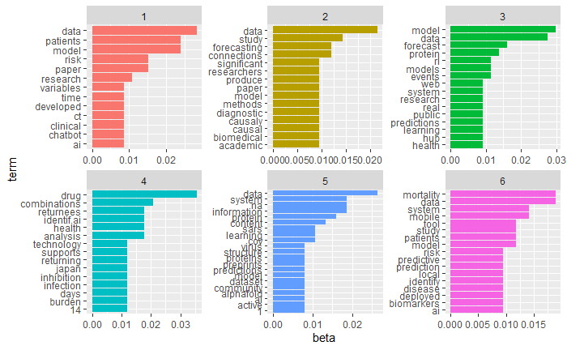

```r
k = 6
topics = LDA(words_dtm,k = k)

word_topics = tidy(topics, matrix = "beta")

topic_terms = word_topics %>%
  group_by(topic) %>%
  slice_max(beta, n = 10) %>%
  ungroup() %>%
  arrange(topic, -beta)

topic_terms %>%
  mutate(term = reorder_within(term, beta, topic)) %>%
  ggplot(aes(beta, term, fill = factor(topic))) +
  geom_col(show.legend = FALSE) +
  facet_wrap(~ topic, scales = "free") +
  scale_y_reordered()
```

# Step 4 (Grouping initiatives (shown as document in the following code) by clusters (shown as topic in the following code))

So far we found the clusters for the words. But we have not grouped the initiatives yet. In this step we will determined that which initiative belongs to each cluster based on the similarities/differences of the words each initiative has. In the following code, “gamma” shows the degree at which each initiative belongs to each cluster. The lower the gamma value is, the less it is likely that that initiative (document) belongs to that cluster (topic).

```r
project_topics = tidy(topics, matrix = "gamma")
project_topics
```

| document | topic | gamma |
| --- | --- | --- |
| 15 | 1 | 9.154616e-05 |
| 4 | 1 | 1.312298e-04 |
| 5 | 1 | 9.993803e-01 |
| 12 | 1 | 1.960473e-04 |
| 3 | 1 | 2.202187e-04 |
| 14 | 1 | 1.293294e-04 |
| 16 | 1 | 1.939188e-04 |
| 20 | 1 | 1.256890e-04 |
| 2 | 1 | 3.127683e-04 |
| 9 | 1 | 9.649174e-05 |

[output cut: 140 more lines]

# Step 5

In this step, we will create a Google Sheet that tells each word belongs to each cluster(s). We need this step in order to depict the clusters in a graphical format.

```r
filtered_words = word_topics %>%
  filter(beta > 0.01)

unique_words = unique(filtered_words$term)
topic_values = rep(NA, length(unique_words))
for (i in 1:length(topic_values)) {
  word = unique_words[i]
  values = filtered_words %>%
    filter(term == word)
  values = values$topic
  values = str_c("Topic ", values)
  topics = str_c(values, collapse = "|")
  topic_values[[i]] = topics
}
word_rows = tibble(
  Label = unique_words,
  Type = "Word",
  Topic = topic_values
  )

topic_labels = 1:k
topic_labels = str_c("Topic ", topic_labels)

topic_rows = tibble(
  Label = topic_labels,
  Type = "Topic",
  Topic = NA,
)

word_output = bind_rows(word_rows, topic_rows)

write_sheet(word_output, "https://docs.google.com/spreadsheets/d/1pNwt1-LH5ksxTPJJGO5wMFdjr7O14Bct5MvWm9uhUC8/edit#gid=0")
```

```
Writing to "word-clustering"
Writing to sheet "Sheet27"
```

# Step 6

In this step, we will create a Google Sheet that tells each initiative belongs to each cluster(s). We need this step in order to depict the clusters in a graphical format.

```r
filtered_projects = project_topics %>%
  filter(gamma > 0.01) %>%
  mutate(Project = str_c("Project ", document)) %>%
  select(Project, topic)

projects = str_c("Project ", 1:25)
topic_values = rep(NA, length(projects))
for (i in 1:length(projects)) {
  project = projects[i]
  values = filtered_projects %>%
    filter(Project == project)
  values = values$topic
  values = str_c("Topic ", values)
  topics = str_c(values, collapse = "|")
  topic_values[[i]] = topics
}
project_rows = tibble(
  Label = projects,
  Type = "Project",
  Topic = topic_values
  )

project_data = data %>%
  mutate(Label = str_c("Project ", row_number())) %>%
  select(Label, Description, Domain, Mission, Name)


project_rows = left_join(project_rows, project_data, by = "Label")

project_rows = project_rows %>%
  select(-Label) %>%
  rename(Label = Name) %>%
  select(Label, Type, Description, Topic, Domain, Mission)

project_output = bind_rows(project_rows, topic_rows) %>%
  mutate(Domain = replace_na(Domain, "Topic"))
write_sheet(project_output, "https://docs.google.com/spreadsheets/d/1p4QQaYk465-qHQmk-Wsh28dlk-z6iAkw6IJC4Dx1XFQ/edit#gid=0", sheet = "project_output")
```

```
Writing to "project_clustering"
Writing to sheet "project_output"
```

# Step 7

In this step, we will create a matrix that tells the degree of similarities/differences between each pair of initiatives. For example, initiative number 15 and 3 are 13% similar corresponding to the word similarities (in terms of Description and Mission definitions).

```r
library(SnowballC)
library(stopwords)
library(text2vec)
tfidf_words = words %>%
  select(-n) %>%
  mutate(word = wordStem(word, language = "en")) %>%
  count(initiative, word, sort = TRUE) %>%
  bind_tf_idf(word, initiative, n)

sparse_matrix = tfidf_words %>%
  cast_sparse(initiative, word, tf)


sparse_matrix[1:10, 1:4]
```

```
10 x 4 sparse Matrix of class "dgCMatrix"
        optim     predict       test     review
15 0.03030303 0.007575758 .          .
3  .          0.057692308 .          .
4  .          0.032258065 .          .
5  .          .           0.02586207 .
7  .          .           .          0.02586207
12 0.01639344 0.032786885 .          .
13 0.01369863 0.013698630 .          .
1  .          .           0.02173913 .
2  .          .           .          .
6  .          .           .          .
```

```r
similarities = sim2(sparse_matrix, method = "cosine", norm = "l2")
#similarities[1:10, 1:4]
as.matrix(similarities)
```

```
           15          3          4          5          7         12         13          1          2          6          8          9
15 1.00000000 0.13179426 0.14607493 0.17161633 0.09032446 0.12315815 0.15845442 0.17048734 0.07127290 0.06996503 0.13211031 0.16620499
3  0.13179426 1.00000000 0.25027389 0.19602308 0.05526971 0.18086571 0.14288631 0.13970014 0.12211366 0.13699755 0.20119818 0.16874858
4  0.14607493 0.25027389 1.00000000 0.24502474 0.09433810 0.16371190 0.18845895 0.13794610 0.10827631 0.06643089 0.19512427 0.13910614
5  0.17161633 0.19602308 0.24502474 1.00000000 0.10448925 0.08141255 0.14471324 0.39444675 0.20023571 0.12718675 0.08490445 0.12105855
7  0.09032446 0.05526971 0.09433810 0.10448925 1.00000000 0.15494413 0.05875580 0.13055824 0.08368992 0.15257207 0.15512631 0.13733544
12 0.12315815 0.18086571 0.16371190 0.08141255 0.15494413 1.00000000 0.12017103 0.07120690 0.13041360 0.09601536 0.09400712 0.14783528
13 0.15845442 0.14288631 0.18845895 0.14471324 0.05875580 0.12017103 1.00000000 0.21376670 0.07727135 0.09102409 0.06684018 0.11212016
1  0.17048734 0.13970014 0.13794610 0.39444675 0.13055824 0.07120690 0.21376670 1.00000000 0.12362451 0.10787198 0.05940885 0.08304548
2  0.07127290 0.12211366 0.10827631 0.20023571 0.08368992 0.13041360 0.07727135 0.12362451 1.00000000 0.18521695 0.13600722 0.10266457
6  0.06996503 0.13699755 0.06643089 0.12718675 0.15257207 0.09601536 0.09102409 0.10787198 0.18521695 1.00000000 0.16021376 0.12317635
8  0.13211031 0.20119818 0.19512427 0.08490445 0.15512631 0.09400712 0.06684018 0.05940885 0.13600722 0.16021376 1.00000000 0.12334092
9  0.16620499 0.16874858 0.13910614 0.12105855 0.13733544 0.14783528 0.11212016 0.08304548 0.10266457 0.12317635 0.12334092 1.00000000
10 0.11465484 0.15960835 0.20003629 0.18237333 0.16828722 0.16062272 0.10876635 0.07733892 0.17262891 0.18249661 0.22973082 0.19267943
11 0.12584556 0.21561439 0.13143760 0.22876984 0.18999015 0.15831026 0.20465542 0.20615528 0.13325932 0.24527623 0.09605842 0.15106116
```

[output cut: 63 more lines]

```r
library(reshape2)
melted_matrix =  melt(as.matrix(similarities))
```

```r
similarity_pairs = melted_matrix %>%
  mutate(self_pair = map2_lgl(Var1, Var2, function(var1, var2) var1 == var2)) %>%
  filter(self_pair == FALSE) %>%
  select(-self_pair) %>%
  rename(initiative1 = Var1, initiative2 = Var2) %>%
  arrange(desc(value))

similarity_pairs
```

| initiative1 | initiative2 | value |
| --- | --- | --- |
| 24 | 23 | 1.00000000 |
| 25 | 23 | 1.00000000 |
| 23 | 24 | 1.00000000 |
| 25 | 24 | 1.00000000 |
| 23 | 25 | 1.00000000 |
| 24 | 25 | 1.00000000 |
| 1 | 5 | 0.39444675 |
| 5 | 1 | 0.39444675 |
| 22 | 6 | 0.34041403 |
| 6 | 22 | 0.34041403 |

[output cut: 590 more lines]

# Step 8 (Adding domain)

Now that we have the clusters, we want to know how similar/different the initiatives are with regards to the Domain variable. We will do so by assigning weights to the two criteria we used so far named Domain and the similarity value between each pair (see above code >>> value column)

```r
catdoms = data %>%
  select(Domain) %>%
  mutate(initiative = row_number())
```

```r
similarity = similarity_pairs %>%
  arrange(desc(value)) %>%
  mutate(PrevP2 = lag(initiative1),PrevP1 = lag(initiative2),
         DuplicatedP1 = initiative1 == PrevP2,
         DuplicatedP2 = initiative2 == PrevP1,
         isDuplicated = DuplicatedP1 & DuplicatedP2,
         isDuplicated = replace_na(isDuplicated, FALSE)) %>%
  filter(!isDuplicated) %>%
  select(-PrevP2, -PrevP1, -DuplicatedP1, -DuplicatedP2, -isDuplicated)
```

```r
map_domain_similarity = function(initiative1, initiative2) {
  Project1Dom = filter(catdoms, initiative == initiative1)$Domain
  Project2Dom = filter(catdoms, initiative == initiative2)$Domain

  return(as.numeric(Project1Dom == Project2Dom))
}

similarity = similarity %>%
  mutate(DomSimilarity = map2_dbl(initiative1, initiative2, map_domain_similarity))
```

```r
text_weight = 0.01
#cat_weight = 0.7
dom_weight = 0.29

similarity = similarity %>%
  rowwise() %>%
  mutate(Overall = value * text_weight + DomSimilarity * dom_weight) %>%
  ungroup() %>%
  arrange(desc(Overall))
similarity
```

| initiative1 | initiative2 | value | DomSimilarity | Overall |
| --- | --- | --- | --- | --- |
| 24 | 23 | 1.00000000 | 1 | 0.3000000000 |
| 23 | 24 | 1.00000000 | 1 | 0.3000000000 |
| 1 | 5 | 0.39444675 | 1 | 0.2939444675 |
| 5 | 1 | 0.39444675 | 1 | 0.2939444675 |
| 22 | 6 | 0.34041403 | 1 | 0.2934041403 |
| 6 | 22 | 0.34041403 | 1 | 0.2934041403 |
| 21 | 6 | 0.26829103 | 1 | 0.2926829103 |
| 6 | 21 | 0.26829103 | 1 | 0.2926829103 |
| 19 | 16 | 0.25334730 | 1 | 0.2925334730 |
| 16 | 19 | 0.25334730 | 1 | 0.2925334730 |

[output cut: 590 more lines]

```r
NA
NA
```

# Step 9

Now that we know each initiative belongs to which cluster(s). So, we can depict it in a graphical way. To do so, we will use Kumu. This has been done automatically by writing the dataframes to google sheets. The kumu map is automatically linked to the google sheet, and will update when it changes.